# Week 5 - Day 1 - Homework

```r
library(tidyverse)
library(CodeClanData)
qb_revenue_breakdown <- CodeClanData::qb_revenue_breakdown
qb_monthly_sales <- CodeClanData::qb_monthly_sales
qb_competitors <- CodeClanData::qb_competitors
qb_device_data <- CodeClanData::qb_device_data
```

# Part 1

Q1 Take the data in the dataset qb_revenue_breakdown and make a stacked bar chart showing the sources of revenue across the two years in the dataset.

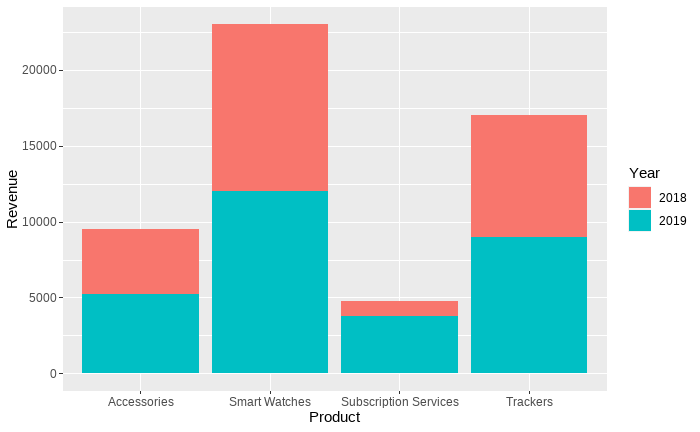

```r
qb_revenue_breakdown %>%
  ggplot() +
  geom_bar(aes(x = Product, y= Revenue, fill = Year), stat = "identity")
```

Q2 Make a line chart showing monthly sales of the “flagship product” - the ‘KwikBit Unit 1’ - over the last year. This data is inside qb_monthly_sales, but you will need to use filter() or subset() (base R).

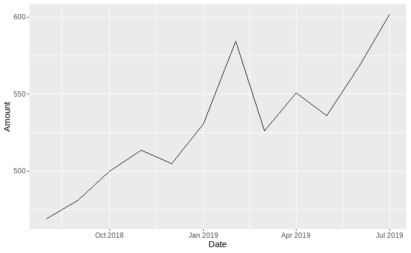

```r
qb_monthly_sales %>%
  filter(Cashflow == "Kwikbit Unit 1 Sales") %>%
  ggplot() +
  geom_line(aes(x = Date, y = Amount))
```

Q3 Make a line chart showing monthly revenue and costs over the last year. This data is also in qb_monthly_sales.

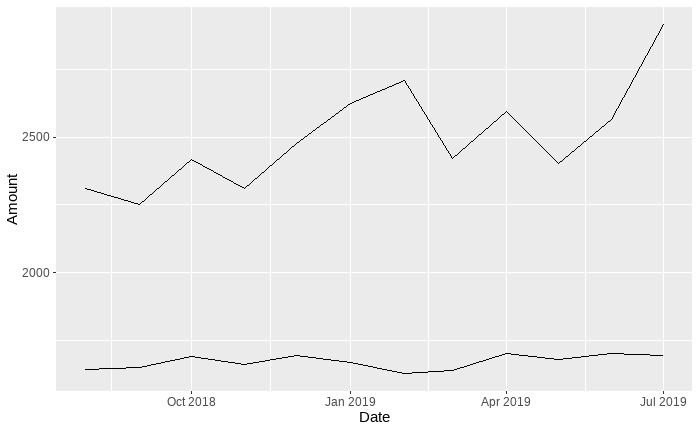

Q4 Show annual sales of personal fitness trackers over the last 5 years broken down by company as a ribbon plot (use geom_area). This data is in qb_competitors.

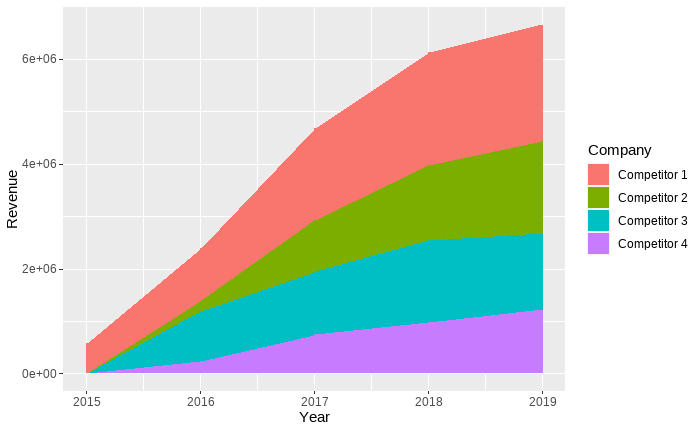

Q5 Now show the sales from the four competitors as a line graph. Include an extra layer that shows the data points used to make the lines.

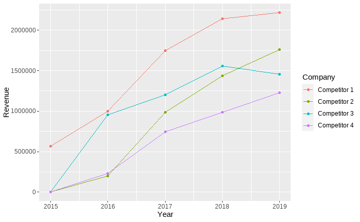

Q6 Now the company wants to compare the number of steps that their device counts vs. their competitors. Make a line graph of the number of steps throughout time, and use faceting to compare between companies and people. The data for this is in qb_device_data.

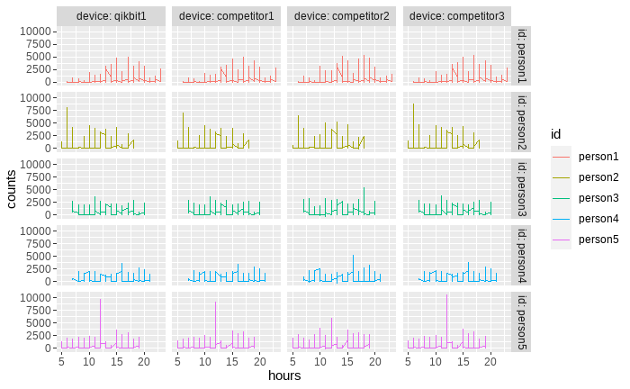

## Part 2

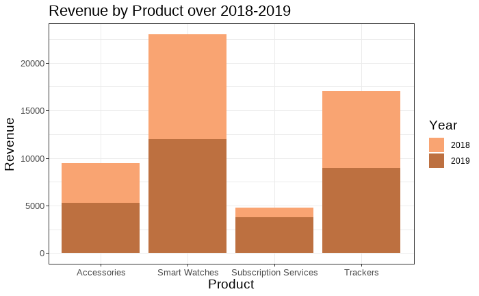

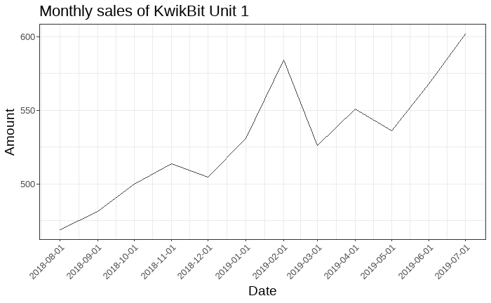

```r
library(scales)
```

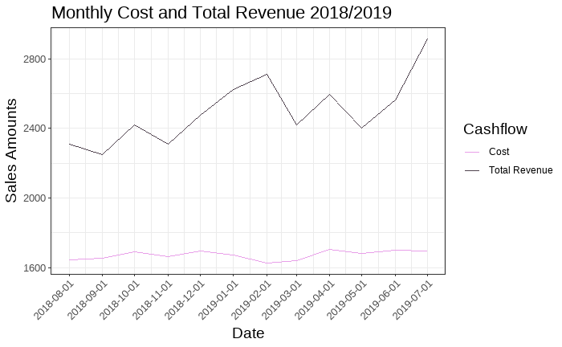

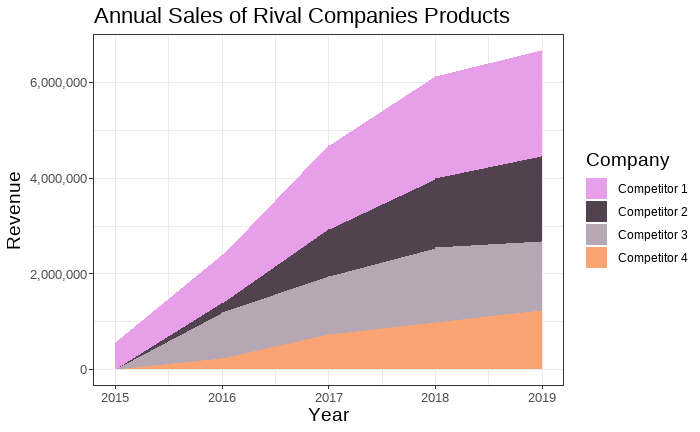

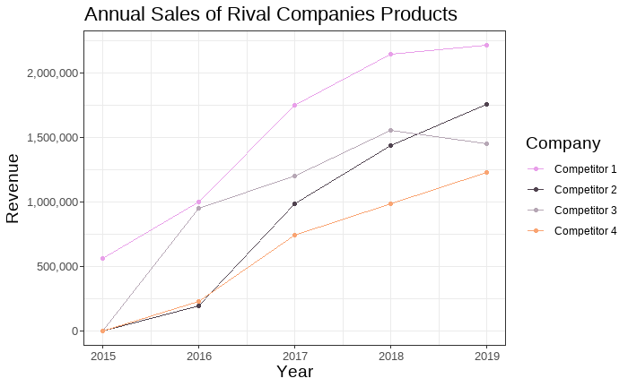

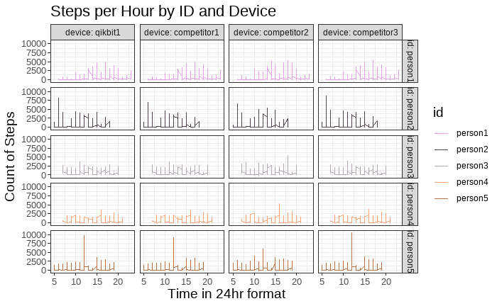